# Analysis of ZNF140 Spec-seq data

Zheng Zuo

Nov 10, 2021

## Background and Experimental design

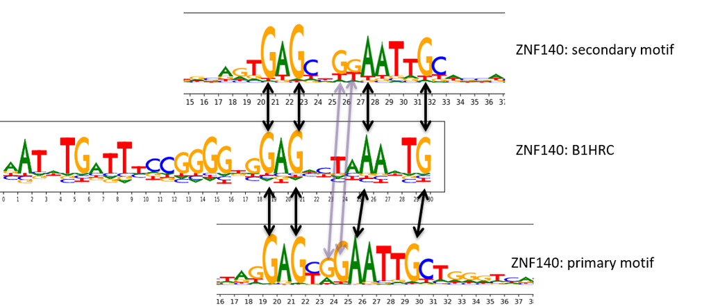

Predicted Motifs by B1H data and Kundaje lab analysis

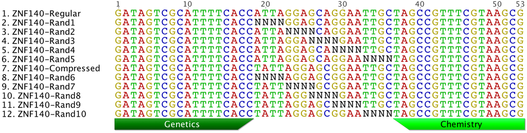

Sequencing libraries design

### Importing processed Spec-seq data of ZNF140

```r
Sample1.processed <- read.csv(file = "ZNF140.replicate1.csv")

Sample2.processed <- read.csv(file = "ZNF140.replicate2.csv")

Sample1.processed
```

| Sequence | Bound | Unbound | Library | B.Ub | pBound | pUnbound | Relative.Energy | Mismatch.Regular | Mismatch.Compressed |
| --- | --- | --- | --- | --- | --- | --- | --- | --- | --- |
| TATTATGAGCGGAATTGC | 701 | 92 | Compressed-2 | 7.61956522 | 1.775299e-03 | 0.0002183380 | -1.5796211043 | 9 | 1 |
| TATTTTGAGCGGAATTGC | 879 | 135 | Compressed-2 | 6.51111111 | 2.226089e-03 | 0.0003203873 | -1.4224119135 | 9 | 2 |
| TTGTAGGAGCGGAATTGC | 987 | 156 | Compressed-1 | 6.32692308 | 2.499601e-03 | 0.0003702253 | -1.3937158265 | 8 | 2 |
| TATTACGAGCGGAATTGC | 474 | 75 | Compressed-2 | 6.32000000 | 1.200416e-03 | 0.0001779930 | -1.3926210024 | 9 | 1 |
| TATTTCGAGCGGAATTGC | 589 | 97 | Compressed-2 | 6.07216495 | 1.491657e-03 | 0.0002302042 | -1.3526169994 | 9 | 2 |
| GGTTAGGAGCGGAATTGC | 636 | 107 | Compressed-1 | 5.94392523 | 1.610685e-03 | 0.0002539366 | -1.3312715232 | 8 | 2 |
| TATTCTGAGCGGAATTGC | 699 | 118 | Compressed-2 | 5.92372881 | 1.770234e-03 | 0.0002800422 | -1.3278679120 | 9 | 2 |
| TATTTAGAGCGGAATTGC | 637 | 109 | Compressed-2 | 5.84403670 | 1.613218e-03 | 0.0002586831 | -1.3143235676 | 9 | 2 |
| TCTTAGGAGCGGAATTGC | 949 | 165 | Compressed-1 | 5.75151515 | 2.403365e-03 | 0.0003915845 | -1.2983651190 | 8 | 1 |
| TATTGGGAGCGGAATTGC | 603 | 108 | Compressed-2 | 5.58333333 | 1.527112e-03 | 0.0002563099 | -1.2686877639 | 7 | 1 |

[output cut: 2451 more lines]

### Summary of Sequencing reads in Bound and Unbound fractions, respectively

```r
Sample1.processed %>%
  group_by(Library) %>%
  summarize("Number of variants in library"=n(),
            "Total Bound reads"=sum(Bound),
            "Total Unbound reads"=sum(Unbound),
            "Bound/Unbound" = sum(Bound)/sum(Unbound))
```

| Library | Number of variants in library | Total Bound reads | Total Unbound reads | Bound/Unbound |
| --- | --- | --- | --- | --- |
| Compressed-1 | 255 | 156499 | 41019 | 3.8152807 |
| Compressed-2 | 255 | 59183 | 40707 | 1.4538777 |
| Compressed-3 | 238 | 16466 | 32284 | 0.5100359 |
| Compressed-4 | 230 | 7815 | 33662 | 0.2321609 |
| Compressed-5 | 225 | 17457 | 31716 | 0.5504162 |
| Compressed(reference) | 1 | 3322 | 721 | 4.6074896 |
| Regular-1 | 255 | 75832 | 55900 | 1.3565653 |
| Regular-2 | 251 | 13039 | 42733 | 0.3051272 |
| Regular-3 | 252 | 20470 | 47095 | 0.4346534 |
| Regular-4 | 250 | 12978 | 50854 | 0.2552012 |

[output cut: 2 more lines]

## Build motif models based on all double variants of consensus sites (Compressed or Regular)

```r
Model_Compressed_Sample1 <- Sample1.processed %>%
  filter(Mismatch.Compressed<=2) %>%
  rename(Energy=`Relative.Energy`) %>%
  TFCookbook::buildEnergyModel()

summary(Model_Compressed_Sample1)
```

```
##
## Call:
## lm(formula = Energy ~ . - Energy, data = .)
##
## Residuals:
##      Min       1Q   Median       3Q      Max
## -0.85738 -0.19527 -0.02386  0.13851  1.28216
##
## Coefficients:
##             Estimate Std. Error t value Pr(>|t|)
## (Intercept) 11.57397    0.90737  12.755  < 2e-16 ***
## `1CG`       -0.02021    0.17046  -0.119 0.905735
## `1CA`        0.02691    0.17046   0.158 0.874697
## `1CT`        0.02438    0.13578   0.180 0.857636
## `2CG`        0.01738    0.17046   0.102 0.918874
## `2CA`        0.10130    0.13578   0.746 0.456310
## `2CT`       -0.15115    0.17046  -0.887 0.376038
## `3CG`        0.01339    0.17046   0.079 0.937460
## `3CA`        0.08272    0.17046   0.485 0.627889
## `3CT`       -0.03180    0.13578  -0.234 0.815037
## `4CG`        0.09582    0.17046   0.562 0.574510
## `4CA`        0.07969    0.17046   0.468 0.640526
## `4CT`       -0.01412    0.13578  -0.104 0.917246
## `5CG`        0.06195    0.17046   0.363 0.716589
## `5CA`        0.13549    0.13565   0.999 0.318804
## `5CT`       -0.16378    0.17046  -0.961 0.337520
## `6CG`        0.13401    0.13565   0.988 0.324089
## `6CA`        0.19411    0.17046   1.139 0.255849
## `6CT`       -0.33590    0.17046  -1.971 0.049831 *
## `7CG`       -1.24353    0.13565  -9.168  < 2e-16 ***
## `7CA`       -0.26080    0.17046  -1.530 0.127234
## `7CT`       -0.23813    0.17046  -1.397 0.163595
## `8CG`       -0.03961    0.12762  -0.310 0.756522
## `8CA`       -0.47520    0.10872  -4.371 1.79e-05 ***
## `8CT`        0.36050    0.12762   2.825 0.005094 **
## `9CG`       -1.18578    0.14977  -7.917 6.98e-14 ***
## `9CA`       -0.45038    0.18557  -2.427 0.015900 *
## `9CT`       -0.80896    0.18152  -4.457 1.24e-05 ***
## `10CG`       1.12629    0.13589   8.288 6.11e-15 ***
## `10CA`       1.50983    0.13589  11.111  < 2e-16 ***
```

[output cut: 16 more lines]

```
## `16CG`      -0.42456    0.19359  -2.193 0.029181 *
## `16CA`      -0.51818    0.19030  -2.723 0.006905 **
## `16CT`      -1.03097    0.16025  -6.434 5.92e-10 ***
## `17CG`      -1.32523    0.15037  -8.813  < 2e-16 ***
## `17CA`      -0.35739    0.18241  -1.959 0.051152 .
## `17CT`      -0.13405    0.18241  -0.735 0.463063
## `18CG`       0.48867    0.13657   3.578 0.000412 ***
## `18CA`       0.82695    0.13657   6.055 4.86e-09 ***
## `18CT`       0.19601    0.13657   1.435 0.152407
## ---
## Signif. codes:  0 '***' 0.001 '**' 0.01 '*' 0.05 '.' 0.1 ' ' 1
##
## Residual standard error: 0.3812 on 261 degrees of freedom
## Multiple R-squared:  0.9149, Adjusted R-squared:  0.8973
## F-statistic: 51.98 on 54 and 261 DF,  p-value: < 2.2e-16
```

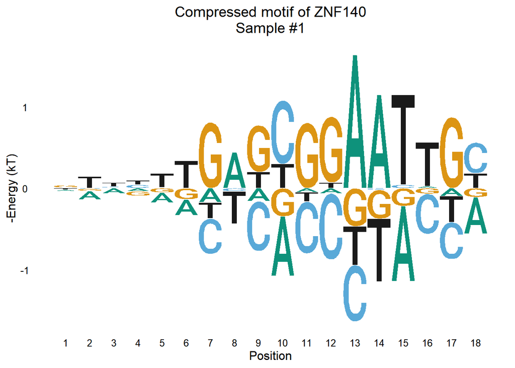

```r
Model_Compressed_Sample1 %>%
  TFCookbook::getEnergyMatrix() %>%
  TFCookbook::plotEnergyLogo() + ggtitle("Compressed motif of ZNF140\nSample #1") + theme(plot.title = element_text(hjust = 0.5))
```

```r
#ggsave("Sample1.compressed.svg", plot=last_plot())
```

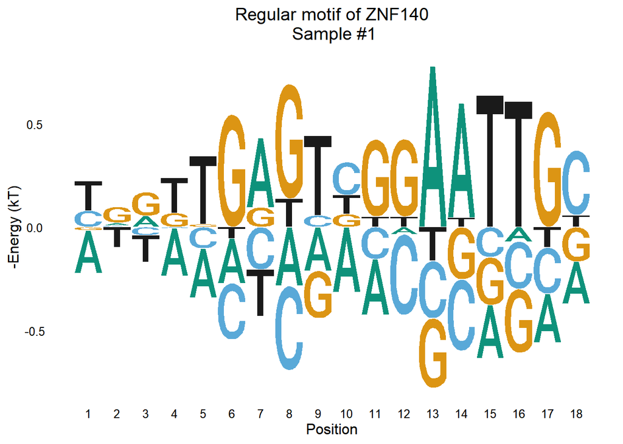

```r
Sample1.processed %>%
  filter(Mismatch.Regular<=2) %>%
  rename(Energy=`Relative.Energy`) %>%
  TFCookbook::buildEnergyModel() -> Model_Regular_Sample1

Model_Regular_Sample1 %>%
  TFCookbook::getEnergyMatrix() %>%
  TFCookbook::plotEnergyLogo() + ggtitle("Regular motif of ZNF140\n Sample #1") + theme(plot.title = element_text(hjust = 0.5))
```

```r
#ggsave("Sample1.regular.svg", plot=last_plot())
```

## Predicting binding energy based on Compressed motif model and compare to Observed energy values

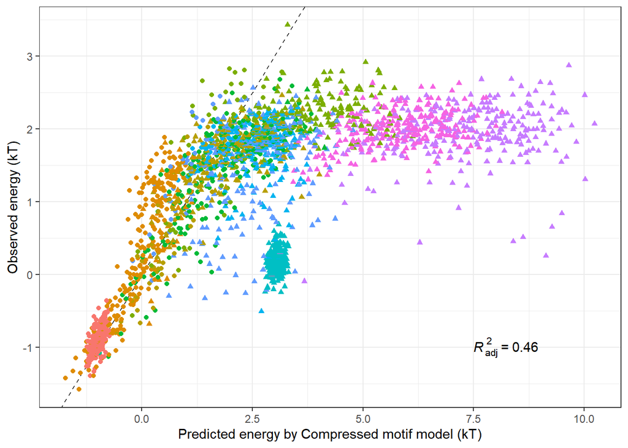

```r
Sample1.processed %<>%
  mutate(`Energy predicted by Compressed Motif` = TFCookbook::predictEnergy(Sequence, Model_Compressed_Sample1),
         `Energy predicted by Regular Motif` = TFCookbook::predictEnergy(Sequence, Model_Regular_Sample1)) %>%
  mutate(`Minimal predicted Energy` = pmin(`Energy predicted by Compressed Motif`, `Energy predicted by Regular Motif`),
         Class = dplyr::if_else(`Energy predicted by Compressed Motif` < `Energy predicted by Regular Motif`, "Compressed site", "Regular site"))

(Sample1.processed %>%
  ggplot(aes(x=`Energy predicted by Compressed Motif`,
                 y=`Relative.Energy`)) +
  theme_bw()+
  geom_abline(intercept = 0 , slope = 1, linetype = "dashed") +
  geom_point(aes(color=Library,
                 shape=Class), show.legend = FALSE) +
  xlab("Predicted energy by Compressed motif model (kT)") +
  ylab("Observed energy (kT)") +
  ggpubr::stat_regline_equation(label.x = 7.5, label.y = -1,
                                aes(label = paste(..adj.rr.label..))) -> plot_Compressed)
```

## Predicting binding energy based on Regular motif model and compare to Measured energy values

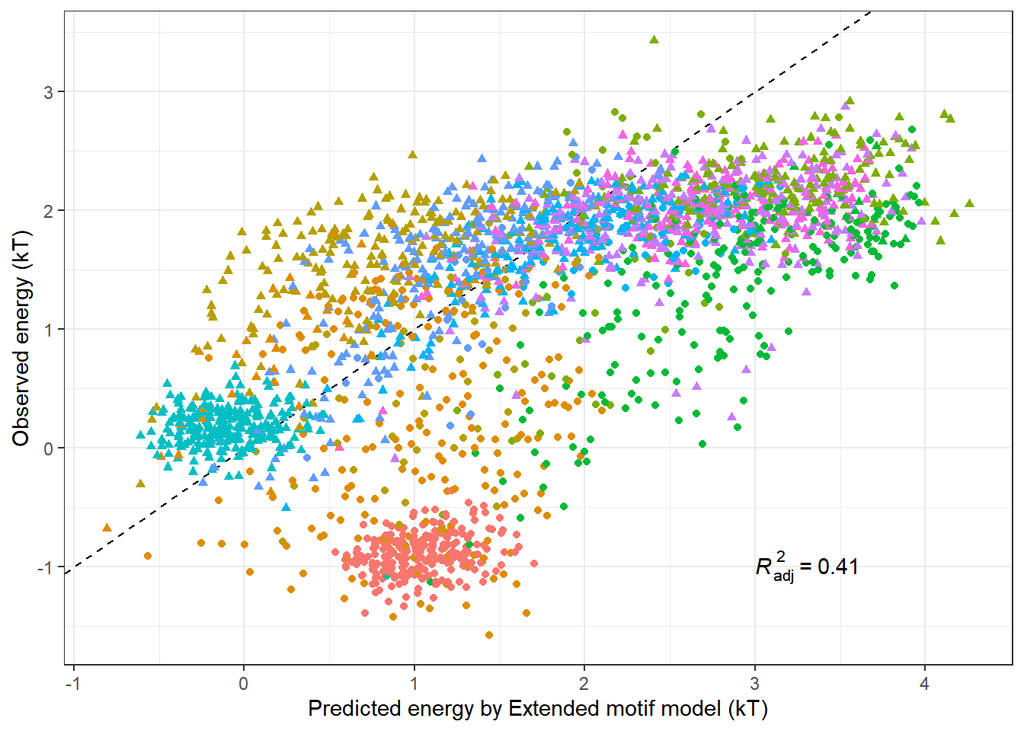

```r
(Sample1.processed %>%
  ggplot(aes(x=`Energy predicted by Regular Motif`,
                 y=`Relative.Energy`)) +
  theme_bw()+
  geom_abline(intercept = 0 , slope = 1, linetype = "dashed") +
  geom_point(aes(color=Library,
                 shape=Class), show.legend = FALSE) +
  xlab("Predicted energy by Extended motif model (kT)") +
  ylab("Observed energy (kT)") +
  ggpubr::stat_regline_equation(label.x = 3, label.y = -1,
                                aes(label = paste(..adj.rr.label..)))
  -> plot_Regular)
```

## Minimum of Two models

Alternatively, if we use the minimal values of predicted Energy from both Compressed Motif and Regular motif, and compare that to the observed binding eneregy values, the correlation gets significantly better.

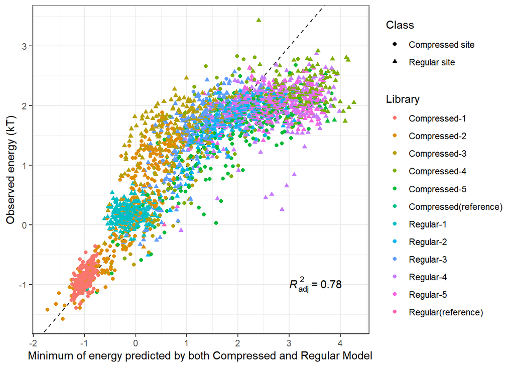

```r
(Sample1.processed %>%
  ggplot(aes(x=`Minimal predicted Energy`,
                 y=`Relative.Energy`)) +
  geom_abline(intercept = 0 , slope = 1, linetype = "dashed") +
  geom_point(aes(color=Library,
                 shape = Class)) +
  ggpubr::stat_regline_equation(label.x = 3, label.y = -1,
                                aes(label = paste(..adj.rr.label..))) +
  scale_x_continuous(breaks = seq(-2,4,1)) +
  theme_bw() +
  xlab("Minimum of energy predicted by both Compressed and Regular Model") +
  ylab("Observed energy (kT)") -> plot_minTwo)
```

Using Compressed Motif model, it is possible to predict the binging energies for all sequences in the libraries. Clearly, small fractions of sites, particularly in R1 library, are predicted to have significantly higher energy than the measured values, which means alternative motif model is required to explain these small group of binding sites by Regular Motif model.

Structurally, above results show that ZNF140 has irregular, variable motifs, and can recognize underlying binding sites in two distinct conformations, i.e., Compressed and Regular conformations.

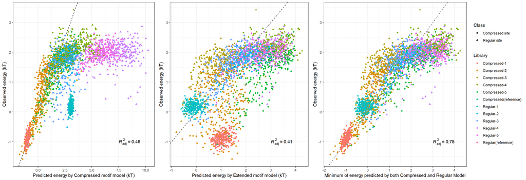

```r
gridExtra::grid.arrange(plot_Compressed, plot_Regular, plot_minTwo, ncol = 3, widths = c(1.02, 1, 1.4)) -> p1
```

```r
#ggsave("ZNF140 Models Predictions vs Observations.svg",plot = p1, height = 6, width = 17.5)
```

## Comparison of observed energy values between Sample 1 and Sample 2

The overall data reproduciblity is quite good ~0.5kT, but not as high as other previous runs, primarily because of high diverisity of sequencing libraries and limited reads overall.

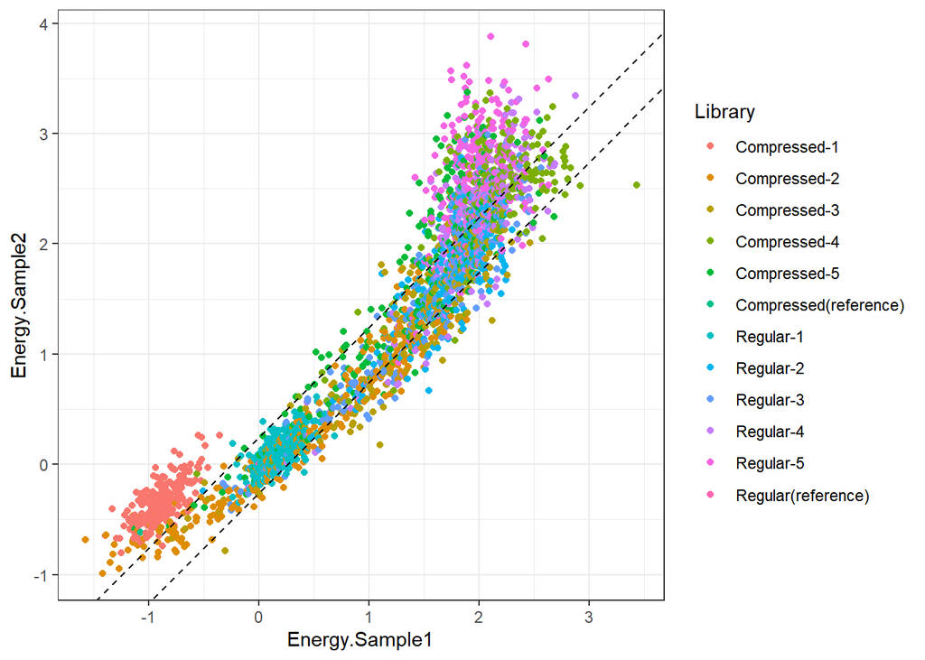

```r
inner_join(Sample1.processed, Sample2.processed, by = "Sequence") %>%
  select(Sequence,
         Energy.Sample1 = `Relative.Energy.x`,
         Energy.Sample2 = `Relative.Energy.y`,
         Library = `Library.x`,
         Mismatch.Compressed = `Mismatch.Compressed.x`) %>%
  ggplot(aes(x = Energy.Sample1, y = Energy.Sample2, color=Library)) +
  geom_point() +
  geom_abline(intercept = -0.25, slope = 1, linetype="dashed") +
  geom_abline(intercept = 0.25, slope = 1, linetype="dashed") +
  theme_bw()
```

## Comparison of model parameters derived from Sample 1 and Sample 2 respectively

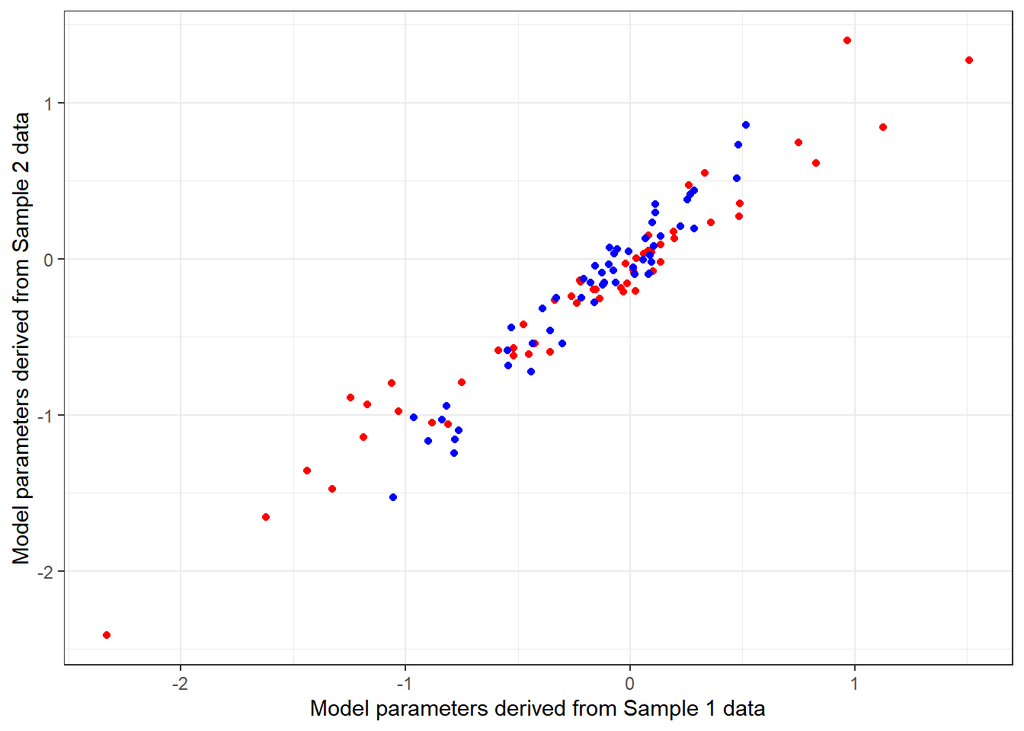

```r
Model_Compressed_Sample2 <- Sample2.processed %>%
  filter(Mismatch.Compressed<=2) %>%
  rename(Energy=`Relative.Energy`) %>%
  TFCookbook::buildEnergyModel()

Model_Regular_Sample2 <- Sample2.processed %>%
  filter(Mismatch.Regular<=2) %>%
  rename(Energy=`Relative.Energy`) %>%
  TFCookbook::buildEnergyModel()


ggplot()+
  geom_point(aes(x = Model_Compressed_Sample1$coefficients[2:55],
                 y = Model_Compressed_Sample2$coefficients[2:55]), color = "red") +
  geom_point(aes(x = Model_Regular_Sample1$coefficients[2:55],
                 y = Model_Regular_Sample2$coefficients[2:55]), color = "blue") +
  theme_bw()+
  xlab("Model parameters derived from Sample 1 data") +
  ylab("Model parameters derived from Sample 2 data")
```